# Juvenile Arrests - Place

## 4.6 Append all subsets of the NIBRS Batch Header File back together and limit to places of interest

The data sets appended below are as follows: + The subset of batch header segment observations for which we were able to match a place to using the LEAIC + The subset of batch header segment observations for which we were able to match a place to using the Urban universe of places + The subset of batch header segment observations for which we were able to match a place to using the GeoCorr county-place crosswalk + The subset of batch header segment observations for which we were not able to match a place to

```r
bhf_place <- bind_rows(
  ba_place_leaic,
  ba_place_urb,
  ba_place_cpxw,
  ba_mis_cpxw
)
```

```r
bhf_place |>
  filter(is.na(place)) |>
  count()
```

```
     n
1 3186
```

Finally, now that we have assigned a place FIPS code to as many agencies in the batch header file as possible, we limit to the places in Urban’s universe of places

```r
bhf_place_urb <- bhf_place |>
  mutate(GEOID = str_c(state_fips, place)) |>
  filter(GEOID %in% urban_places$GEOID)
```

## 4.7 Join agency-level arrests for all years onto the place-agency file

Join arrests onto the full universe of place-agencies.

```r
arrests_agency_place <- left_join(
  x = bhf_place_urb,
  y = arrests_juv_agency,
  by = c("ori", "year")
)
```

## 4.8 Aggregate from agency-level to place-level

Now that we have joined our agency-level juvenile arrests data onto the full universe of place-agencies, we can aggregate the counts from the agency to the place level.

```r
# Count number of arrests from reporting agencies in each place
arrests_place <- arrests_agency_place |>
  group_by(year, GEOID) |>
  summarize(across(starts_with("arr"), ~sum(.x, na.rm=TRUE))) |>
  ungroup()
```

# 5. Calculate rates

## 5.1 Get population denominators from ACS

This section relies on the `tidycensus` package, which requires a Census API key. You can acquire a key [here](https://api.census.gov/data/key_signup.html) and learn more about installing your key [here](https://walker-data.com/tidycensus/reference/census_api_key.html). Replace `[YOUR-KEY-HERE]` in the code below with your Census API key (leave the quotation marks).

```r
# set Census API once
# tidycensus::census_api_key("[YOUR-KEY-HERE]", install=TRUE, overwrite = TRUE)
```

### 5.1a Check ACS variable names and identify those we need

Load ACS variables for our first and last years. Manually explore each file and spot check several observations. The naming conventions of ACS variables do not seem to change during our time period. Note that if they did we would need to split up the code that reads in the years below.

```r
# Check ACS variables for the first and last years to see if they change over time
variables_fy <- tidycensus::load_variables(2021, "acs5")
variables_ly <- tidycensus::load_variables(2024, "acs5")

test_fy <- variables_fy |> filter(name %in% c("B01003_001", "B01001_005", "B01001_006", "B01001_029", "B01001_030", "B01001A_005", "B01001B_005", "B01001C_005", "B01001D_005", "B01001E_005"))

rm(test_fy)

test_ly <- variables_ly |> filter(name %in% c("B01003_001", "B01001_005", "B01001_006", "B01001_029", "B01001_030", "B01001A_005", "B01001B_005", "B01001C_005", "B01001D_005", "B01001E_005"))
```

First create vectors for years and variables of interest

```r
# Create a list of all our years
years <- lst(2021, 2022, 2023, 2024)

# Create a vector for our ACS variables of interest
my_vars <- c(
  total_people = "B01003_001",
  age_m_1014 = "B01001_005",
  age_m_1517 = "B01001_006",
  age_f_1014 = "B01001_029",
  age_f_1517 = "B01001_030",
  age_m_1014_white = "B01001A_005",
  age_m_1014_black = "B01001B_005",
  age_m_1014_aian = "B01001C_005",
  age_m_1014_asin = "B01001D_005",
  age_m_1014_nhpi = "B01001E_005",
  age_m_1014_othr = "B01001F_005",
  age_m_1014_twom = "B01001G_005",
  age_m_1014_white_nh = "B01001H_005",
  age_m_1014_hispanic = "B01001I_005",
  age_m_1517_white = "B01001A_006",
  age_m_1517_black = "B01001B_006",
  age_m_1517_aian = "B01001C_006",
  age_m_1517_asin = "B01001D_006",
  age_m_1517_nhpi = "B01001E_006",
  age_m_1517_othr = "B01001F_006",
  age_m_1517_twom = "B01001G_006",
  age_m_1517_white_nh = "B01001H_006",
  age_m_1517_hispanic = "B01001I_006",
  age_f_1014_white = "B01001A_020",
  age_f_1014_black = "B01001B_020",
  age_f_1014_aian = "B01001C_020",
  age_f_1014_asin = "B01001D_020",
  age_f_1014_nhpi = "B01001E_020",
  age_f_1014_othr = "B01001F_020",
  age_f_1014_twom = "B01001G_020",
  age_f_1014_white_nh = "B01001H_020",
  age_f_1014_hispanic = "B01001I_020",
  age_f_1517_white = "B01001A_021",
  age_f_1517_black = "B01001B_021",
  age_f_1517_aian = "B01001C_021",
  age_f_1517_asin = "B01001D_021",
  age_f_1517_nhpi = "B01001E_021",
  age_f_1517_othr = "B01001F_021",
  age_f_1517_twom = "B01001G_021",
  age_f_1517_white_nh = "B01001H_021",
  age_f_1517_hispanic = "B01001I_021"
)
```

```r
# Pull data
acs_pops_full <- map_dfr(
  years,
  ~ tidycensus::get_acs(
    geography = "place",
    variables = my_vars,
    year = .x,
    survey = "acs5",
    output = "wide",
    geometry = FALSE
  ),
  # Create a year variable for each year
  .id = "year"
)

# Remove Puerto Rico from ACS data
acs_pops <- acs_pops_full |>
  mutate(state_fips = substr(GEOID, 1, 2)) |>
  filter(state_fips != "72")

# Remove obsolete files
#rm(variables_fy, variables_ly, years, my_vars)

rm(years, my_vars, acs_pops_full)
```

### 5.1c Clean ACS data and create subgroups

Clean variable names and drop margins of error

```r
acs_pops <- acs_pops |>
  rename_with(~ sub("E$", "", .x), everything()) |>
  select(-c(ends_with("M")))
```

For the rate of juvenile arrests per 100,000 juveniles metric, we want subgroups by race, sex, and age subgroups. These are subgroups of all observations ages 10-17, so the sum of each subgroup should equal the total number of observations ages 10-17.

- Race: white, Black, Hispanic, Asian/other
- Sex: male, female
- Age: ages 10-14, ages 15-17

Note that there is a Non-Hispanic white category, but not a Non-Hispanic category for other races (Black, Asian, etc.). This means that the categories will have a small but non-zero overlap. The race/ethnicity categories actually used in the `juvenile-arrests` metric are white, Black, Asian/other, and Hispanic. These are not mutually exclusive (e.g., someone could be counted as both Black and Hispanic), which matches the population denominators created here (this is because ACS doesn’t have counts of non-Hispanic Black or other non-Hispanic races other than white).

```r
# Create the total for ages 10-17 and the race, sex, and age subgroups
acs_pops <- acs_pops |>
  mutate(
    # Total age 10-17
    pop_1017 = age_m_1014 + age_m_1517 + age_f_1014 + age_f_1517,
    # Race subgroups
    pop_1017_white = age_m_1014_white + age_m_1517_white + age_f_1014_white + age_f_1517_white,
    pop_1017_black = age_m_1014_black + age_m_1517_black + age_f_1014_black + age_f_1517_black,
    pop_1017_aian = age_m_1014_aian + age_m_1517_aian + age_f_1014_aian + age_f_1517_aian,
    pop_1017_asin = age_m_1014_asin + age_m_1517_asin + age_f_1014_asin + age_f_1517_asin,
    pop_1017_nhpi = age_m_1014_nhpi + age_m_1517_nhpi + age_f_1014_nhpi + age_f_1517_nhpi,
    pop_1017_othr = age_m_1014_othr + age_m_1517_othr + age_f_1014_othr + age_f_1517_othr,
    pop_1017_hispanic = age_m_1014_hispanic + age_m_1517_hispanic + age_f_1014_hispanic + age_f_1517_hispanic,
    # Sex subgroups
    pop_1017_male = age_m_1014 + age_m_1517,
    pop_1017_female = age_f_1014 + age_f_1517,
    # Age subgroups
    pop_1017_1014 = age_m_1014 + age_f_1014,
    pop_1017_1517 = age_m_1517 + age_f_1517
  ) |>
  # Edit race variables
  mutate(
    # Manually create "two or more" race variable
    pop_1017_twom = pop_1017 - pop_1017_white - pop_1017_black -
      pop_1017_aian - pop_1017_asin - pop_1017_nhpi - pop_1017_othr,
    # Combine all asian races, other races, and two or more races
    pop_1017_asian_other = pop_1017_aian + pop_1017_asin + pop_1017_nhpi +
      pop_1017_othr + pop_1017_twom
  ) |>
  select(-c(starts_with("age"), pop_1017_aian, pop_1017_asin, pop_1017_nhpi, pop_1017_othr, pop_1017_twom))
```

```r
# Limit places to those in the Urban file
acs_pops <- acs_pops |>
  filter(GEOID %in% urban_places$GEOID)
```

### 5.1d Join denominators and arrest counts

```r
arrests_place_demo <- left_join(
  x = acs_pops,
  y = arrests_place |>
    mutate(year = as.character(year)),
  by = c("year", "GEOID")
)
```

## 5.2 Calculate juvenile arrest rates

Each instance of an arrest, citation, or summons for an offense is counted as an arrest. Note that an individual can be arrested more than once and therefore the rates constructed are of arrests, not of persons arrested. Arrest rates are calculated for all offense types available in NIBRS data, including offenses against property, persons, and society.

Calculate arrest rates per 100,000 juveniles. If no agencies in a place reported (out of all agencies, including those with only non-juvenile arrests), the value is set to `NA`. We also calculate rates for the following subgroups:

- Race: white, Black, Hispanic, Asian/other
- Sex: male, female
- Age: ages 10-14, ages 15-17

```r
# Calculate arrest rates (per 100,000 people) and subgroups for agencies that reported
arrest_rates_place <- arrests_place_demo |>
  mutate(
    # Total ages 10-17
    rate_juv_arrest = arr_total_juv / pop_1017 * 100000,
    # Race/ethnicity subgroups
    rate_juv_arrest_white = arr_white / pop_1017_white * 100000,
    rate_juv_arrest_black = arr_black / pop_1017_black * 100000,
    rate_juv_arrest_hispanic  = arr_hispanic / pop_1017_hispanic * 100000,
    rate_juv_arrest_asian_other = arr_asian_other / pop_1017_asian_other * 100000,
    # Sex subgroups
    rate_juv_arrest_male = arr_male / pop_1017_male * 100000,
    rate_juv_arrest_female = arr_female / pop_1017_female * 100000,
    # Age subgroups
    rate_juv_arrest_1014 = arr_1014 / pop_1017_1014 * 100000,
    rate_juv_arrest_1517 = arr_1517 / pop_1017_1517 * 100000
  )
```

Replace the rates of observations with a population less than 30 with `NA`.

```r
# Suppress data using populations < 30 people
arrest_rates_place <- arrest_rates_place |>
  mutate(
    rate_juv_arrest = ifelse(pop_1017 < 30, NA, rate_juv_arrest),
    rate_juv_arrest_white = ifelse(pop_1017_white < 30, NA, rate_juv_arrest_white),
    rate_juv_arrest_black = ifelse(pop_1017_black < 30, NA, rate_juv_arrest_black),
    rate_juv_arrest_hispanic = ifelse(pop_1017_hispanic < 30, NA, rate_juv_arrest_hispanic),
    rate_juv_arrest_asian_other = ifelse(pop_1017_asian_other < 30, NA, rate_juv_arrest_asian_other),
    rate_juv_arrest_male = ifelse(pop_1017_male < 30, NA, rate_juv_arrest_male),
    rate_juv_arrest_female = ifelse(pop_1017_female < 30, NA, rate_juv_arrest_female),
    rate_juv_arrest_1014 = ifelse(pop_1017_1014 < 30, NA, rate_juv_arrest_1014),
    rate_juv_arrest_1517 = ifelse(pop_1017_1517 < 30, NA, rate_juv_arrest_1517)
  )
```

## 6. Construct quality indicators

This section constructs an indicator used to assess the quality of data for each place. Places with 100% of agencies reporting are coded as 1; places with 80% or more of agencies reporting OR 100% of core agencies reporting are coded as 2; places with less than 80% of agencies reporting are coded as 3; places with 0% of agencies reporting (or no agencies in the place) are coded as `NA`.

### 6.1 Calculate reporting rate for all agencies

The quality indicator for this metric is based on the number of agencies reporting. We can’t use the agency-level juvenile arrests data for this, because agencies may have zero juvenile arrests and thus be excluded but still have reported arrests for other ages. Instead, we use the full arrests file (i.e., all arrests and not just juvenile arrests) to calculate agency reporting rates.

```r
arrests_all_agency <- arrests_all |>
  group_by(year, ori) |>
  summarize(arr_total_any = n()) |>
  ungroup()
```

Join total number of arrests for each agency onto the place/agency file.

```r
arrests_all_agency_place <- left_join(
   x = bhf_place_urb,
   y = arrests_all_agency,
   by = c("ori", "year")
 ) |>
  mutate(
    # Create variables for reporting by place-agency. If the count of total arrests (any, not just juvenile) is missing, we indicate that the agency did not report in that year
    reporting = ifelse(is.na(arr_total_any), 0, 1)
    )
```

Aggregate variables to the place level.

```r
# Summarize by place
arrests_all_place <- arrests_all_agency_place |>
  group_by(year, state_fips, place) |>
  summarize(
    n = n(),
    n_reporting = sum(reporting),
    n_core_city = sum(core_city),
    n_core_city_rpt = sum(core_city==1 & reporting==1),
    across(arr_total_any, ~sum(.x, na.rm=TRUE))
  ) |>
  mutate(
    agencies_reporting = n_reporting / n,
    core_reporting = n_core_city_rpt / n_core_city,
    core_reporting = ifelse(is.nan(core_reporting), NA, core_reporting),
    GEOID = str_c(state_fips, place)
  ) |>
  ungroup()
```

Join total arrests back to juvenile arrest file

```r
# Join all arrests and juvenile arrests
arrest_rates_place <- left_join(
  x = arrest_rates_place,
  y = arrests_all_place |>
    mutate(year = as.character(year)),
  by = c("year", "GEOID", "state_fips")
)
```

### 6.2 Construct the quality indicator

Construct the quality indicator.

```r
# Construct quality with core reporting
arrest_rates_place <- arrest_rates_place |>
  mutate(
    rate_juv_arrest_quality = case_when(
      agencies_reporting == 1 ~ 1,
      agencies_reporting >= 0.8 | core_reporting==1 ~ 2,
      agencies_reporting > 0 ~ 3,
      agencies_reporting == 0 ~ NA_real_
      ),
    rate_juv_arrest_quality = ifelse(pop_1017 < 30, NA, rate_juv_arrest_quality)
  )
```

```r
arrest_rates_place <- arrest_rates_place |>
  mutate(across(starts_with("rate"),
                ~ifelse(is.na(rate_juv_arrest_quality), NA, .x)),
         )
```

Most places (in our universe) had 100 percent of agencies reporting.

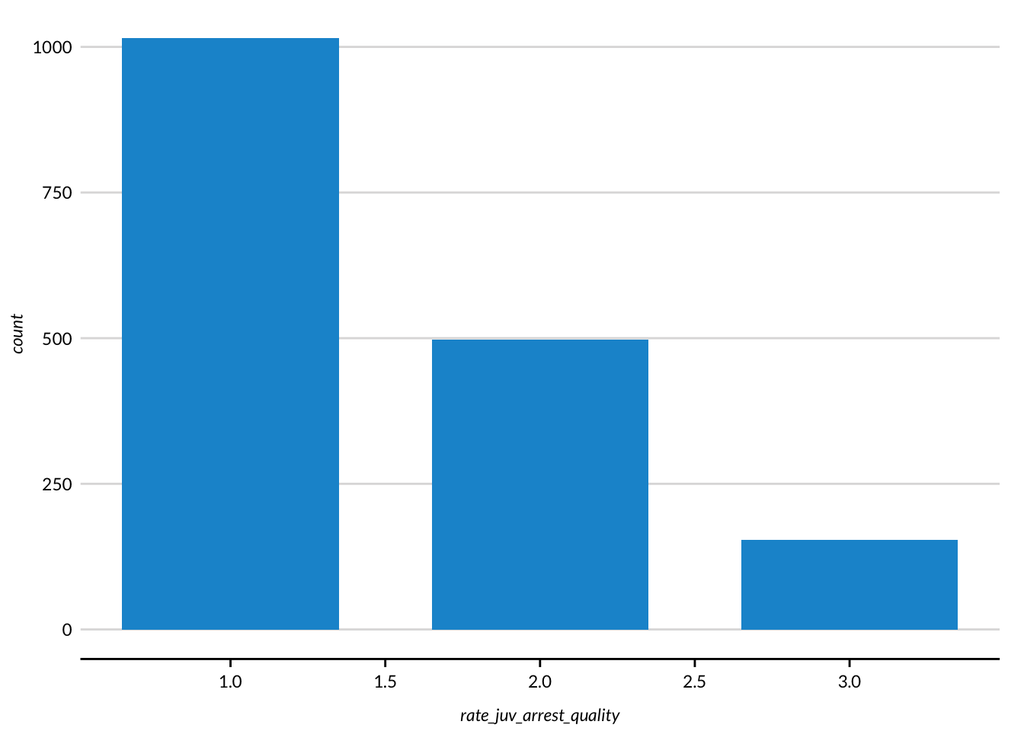

```r
arrest_rates_place |>
  group_by(year) |>
  ggplot(aes(x = rate_juv_arrest_quality)) +
  geom_bar()
```

## 7. Validation

This section performs several checks on the calculated rates of juvenile arrests.

Checking arrest rates for all juveniles

```r
arrest_rates_place |>
  group_by(year) |>
  summarise(
    quantiles = list(
      quantile(rate_juv_arrest, probs = c(0, 0.2, 0.4, 0.6, 0.8, 0.9, 0.99, 1), na.rm = TRUE)
    )
  ) %>%
  unnest_wider(quantiles)
```

```
# A tibble: 4 × 9
  year   `0%` `20%` `40%` `60%` `80%` `90%` `99%` `100%`
  <chr> <dbl> <dbl> <dbl> <dbl> <dbl> <dbl> <dbl>  <dbl>
1 2021      0  258.  703. 1164. 2055. 2886. 5490. 11200.
2 2022      0  344.  806. 1366. 2366. 3243. 6866. 19138.
3 2023      0  502.  998. 1552. 2582. 3503. 6605. 21894.
4 2024      0  537.  990. 1533. 2522. 3369. 6134. 19800.
```

Checking arrest rates for white juveniles

```r
arrest_rates_place |>
  group_by(year) |>
  summarise(
    quantiles = list(
      quantile(rate_juv_arrest_white, probs = c(0, 0.2, 0.4, 0.6, 0.8, 0.9, 0.99, 1), na.rm = TRUE)
    )
  ) %>%
  unnest_wider(quantiles)
```

```
# A tibble: 4 × 9
  year   `0%` `20%` `40%` `60%` `80%` `90%`  `99%` `100%`
  <chr> <dbl> <dbl> <dbl> <dbl> <dbl> <dbl>  <dbl>  <dbl>
1 2021      0  181.  571. 1074. 2022. 2737.  5469.  9501.
2 2022      0  286.  727. 1398. 2506. 3578.  7852. 14543.
3 2023      0  421. 1006. 1782. 3069. 4621. 11484. 19270.
4 2024      0  586. 1203. 2005. 3513. 5332. 11171. 17534.
```

Checking arrest rates for Black juveniles.

```r
arrest_rates_place |>
  group_by(year) |>
  summarise(
    quantiles = list(
      quantile(rate_juv_arrest_black, probs = c(0, 0.2, 0.4, 0.6, 0.8, 0.9, 0.99, 1), na.rm = TRUE)
    )
  ) %>%
  unnest_wider(quantiles)
```

```
# A tibble: 4 × 9
  year   `0%` `20%` `40%` `60%`  `80%`  `90%`  `99%` `100%`
  <chr> <dbl> <dbl> <dbl> <dbl>  <dbl>  <dbl>  <dbl>  <dbl>
1 2021      0  710. 1857. 3671.  6172. 11364. 32898. 42969.
2 2022      0  933. 2345. 4326.  8294. 12549. 32646. 60096.
3 2023      0 1468. 3056. 5683.  9534. 15183. 34959. 80000
4 2024      0 1467. 3160. 5249. 10199. 15153. 36671. 78788.
```

Checking arrest rates for Hispanic juveniles

```r
arrest_rates_place |>
  group_by(year) |>
  summarise(
    quantiles = list(
      quantile(rate_juv_arrest_hispanic, probs = c(0, 0.2, 0.4, 0.6, 0.8, 0.9, 0.99, 1), na.rm = TRUE)
    )
  ) %>%
  unnest_wider(quantiles)
```

```
# A tibble: 4 × 9
  year   `0%` `20%` `40%` `60%` `80%` `90%` `99%` `100%`
  <chr> <dbl> <dbl> <dbl> <dbl> <dbl> <dbl> <dbl>  <dbl>
1 2021      0     0  91.4  399. 1115. 1692. 4584.  5392.
2 2022      0     0 114.   505. 1383. 2379. 6372. 11628.
3 2023      0     0 165.   725. 1576. 2606. 6817.  9235.
4 2024      0     0 226.   699. 1589. 2681. 5757. 11078.
```

Checking arrest rates for Asian/other race juveniles

```r
arrest_rates_place |>
  group_by(year) |>
  summarise(
    quantiles = list(
      quantile(rate_juv_arrest_asian_other, probs = c(0, 0.2, 0.4, 0.6, 0.8, 0.9, 0.99, 1), na.rm = TRUE)
    )
  ) %>%
  unnest_wider(quantiles)
```

```
# A tibble: 4 × 9
  year   `0%` `20%` `40%` `60%` `80%` `90%` `99%` `100%`
  <chr> <dbl> <dbl> <dbl> <dbl> <dbl> <dbl> <dbl>  <dbl>
1 2021      0     0  10.3  55.8  150.  297. 3585.  9084.
2 2022      0     0  15.1  54.2  165.  301. 3143.  9340.
3 2023      0     0  25.3  68.3  159.  315. 2874.  8975.
4 2024      0     0  26.8  68.1  148.  277. 2988.  7374.
```

Checking arrest rates for male juveniles

```r
arrest_rates_place |>
  group_by(year) |>
  summarise(
    quantiles = list(
      quantile(rate_juv_arrest_male, probs = c(0, 0.2, 0.4, 0.6, 0.8, 0.9, 0.99, 1), na.rm = TRUE)
    )
  ) %>%
  unnest_wider(quantiles)
```

```
# A tibble: 4 × 9
  year   `0%` `20%` `40%` `60%` `80%` `90%` `99%` `100%`
  <chr> <dbl> <dbl> <dbl> <dbl> <dbl> <dbl> <dbl>  <dbl>
1 2021      0  347.  986. 1637. 2866. 3867. 6622. 12776.
2 2022      0  491. 1133. 1892. 3052. 4387. 8417. 21200.
3 2023      0  716. 1419. 2097. 3366. 4710. 7243. 23298.
4 2024      0  777. 1457. 2110. 3347. 4449. 7640. 21887.
```

Checking arrest rates for female juveniles

```r
arrest_rates_place |>
  group_by(year) |>
  summarise(
    quantiles = list(
      quantile(rate_juv_arrest_female, probs = c(0, 0.2, 0.4, 0.6, 0.8, 0.9, 0.99, 1), na.rm = TRUE)
    )
  ) %>%
  unnest_wider(quantiles)
```

```
# A tibble: 4 × 9
  year   `0%` `20%` `40%` `60%` `80%` `90%` `99%` `100%`
  <chr> <dbl> <dbl> <dbl> <dbl> <dbl> <dbl> <dbl>  <dbl>
1 2021      0  114.  347.  672. 1275. 1943. 4207.  9630.
2 2022      0  143.  400.  851. 1557. 2171. 5455. 17010.
3 2023      0  215.  495.  962. 1762. 2453. 6211. 20449.
4 2024      0  240.  555.  953. 1724. 2292. 5324. 17714.
```

Checking arrest rates for juveniles aged 10-14

```r
arrest_rates_place |>
  group_by(year) |>
  summarise(
    quantiles = list(
      quantile(rate_juv_arrest_1014, probs = c(0, 0.2, 0.4, 0.6, 0.8, 0.9, 0.99, 1), na.rm = TRUE)
    )
  ) %>%
  unnest_wider(quantiles)
```

```
# A tibble: 4 × 9
  year   `0%` `20%` `40%` `60%` `80%` `90%` `99%` `100%`
  <chr> <dbl> <dbl> <dbl> <dbl> <dbl> <dbl> <dbl>  <dbl>
1 2021      0  73.5  271.  583. 1095. 1651. 4144.  6772.
2 2022      0 125.   351.  664. 1253. 1929. 4937. 11454.
3 2023      0 179.   444.  828. 1458. 2203. 5198. 14105.
4 2024      0 190.   432.  778. 1443. 2076. 4099. 13177.
```

Checking arrest rates for juveniles aged 15-17

```r
arrest_rates_place |>
  group_by(year) |>
  summarise(
    quantiles = list(
      quantile(rate_juv_arrest_1517, probs = c(0, 0.2, 0.4, 0.6, 0.8, 0.9, 0.99, 1), na.rm = TRUE)
    )
  ) %>%
  unnest_wider(quantiles)
```

```
# A tibble: 4 × 9
  year   `0%` `20%` `40%` `60%` `80%` `90%`  `99%` `100%`
  <chr> <dbl> <dbl> <dbl> <dbl> <dbl> <dbl>  <dbl>  <dbl>
1 2021      0  494. 1331. 2214. 3678. 5235.  8462. 19382.
2 2022      0  702. 1526. 2509. 4146. 5575. 10687. 32460.
3 2023      0  964. 1877. 2778. 4389. 5993. 10118. 34556.
4 2024      0 1062. 1932. 2839. 4338. 5633. 10039. 29857.
```

There is less missingness over time. This makes sense, because more agencies report to NIBRS over time.

```r
arrest_rates_place |>
  filter(is.na(rate_juv_arrest)) |>
  group_by(year) |>
  count()
```

```
# A tibble: 4 × 2
# Groups:   year [4]
  year      n
  <chr> <int>
1 2021    116
2 2022     63
3 2023     54
4 2024     44
```

The rate of missingness is the same for the quality variable.

```r
arrest_rates_place |>
  filter(is.na(rate_juv_arrest_quality)) |>
  group_by(year) |>
  count()
```

```
# A tibble: 4 × 2
# Groups:   year [4]
  year      n
  <chr> <int>
1 2021    116
2 2022     63
3 2023     54
4 2024     44
```

## 8. Save and write out data

```r
arrest_rates_place_all <- arrest_rates_place |>
  select(c(year, GEOID, starts_with("rate"), starts_with("pop"))) |>
  mutate(
    state = substr(GEOID, 1, 2),
    place = substr(GEOID, 3, 7)
  )
```

Create a subset without subgroup rates and write out this data set

```r
# File with only total juvenile arrest rates
juv_arrest_place <- arrest_rates_place_all |>
  select(
    year,
    state,
    place,
    rate_juv_arrest,
    rate_juv_arrest_quality
  )
```

```r
evaluate_final_data(
  exp_form_path = "10a_final-evaluation/evaluation_form_rate_arrests_overall_place.csv",
  data = juv_arrest_place,
  geography = "place",
  subgroups = FALSE,
  confidence_intervals = FALSE
  )
```

```
[1] "This data passes all tests!"
```

```r
# Write out this data set
juv_arrest_place |>
  write_csv(here::here("24_just-policing",
                      "data",
                       "final",
                       "rate_arrests_place_all.csv"))
```

Create a file that is long by subgroup and write it out

```r
# pivot longer subgroup arrest rates
juv_arrest_all_subgroup <- arrest_rates_place_all |>
  mutate(rate_juv_arrest_all = rate_juv_arrest) |>
  select(
    year,
    state,
    place,
    rate_juv_arrest_all,
    rate_juv_arrest_white,
    rate_juv_arrest_black,
    rate_juv_arrest_asian_other,
    rate_juv_arrest_hispanic,
    rate_juv_arrest_male,
    rate_juv_arrest_female,
    rate_juv_arrest_1014,
    rate_juv_arrest_1517,
    quality = rate_juv_arrest_quality
  ) |>
  pivot_longer(cols = contains("rate_juv_arrest_"),
               names_to = "subgroup",
               values_to = "rate_juv_arrest",
               values_drop_na = TRUE,
               names_pattern = "rate_juv_arrest_(.*)") |>
  rename(rate_juv_arrest_quality = quality)

acs_pops_subgroup <- acs_pops |>
  mutate(pop_1017_all = pop_1017) |>
  pivot_longer(cols = contains("pop_1017_"),
               names_to = "subgroup",
               values_to = "pop",
               values_drop_na = TRUE,
               names_pattern = "pop_1017_(.*)") |>
  mutate(state = str_sub(GEOID, start = 1, end = 2), place = str_sub(GEOID, start = 3, end = 7)) |>
  select(year, state, place, subgroup, pop)

# combine into one file
# replace quality indicators with missing if subgroup population < 30
juv_arrest_place_all_subgroup <- left_join(
  x = acs_pops_subgroup,
  y = juv_arrest_all_subgroup,
  by = c("year", "state", "place", "subgroup")
) |>
  mutate(
    subgroup_type = case_when(
      subgroup %in% c("all") ~ "all",
      subgroup %in% c("white", "black", "asian_other", "hispanic") ~ "race-ethnicity",
      subgroup %in% c("male", "female") ~ "gender",
      subgroup %in% c("1014", "1517") ~ "age",
    ),
    subgroup = case_when(
      subgroup == "all" ~ "All",
      subgroup == "white" ~ "White",
      subgroup == "black" ~ "Black",
      subgroup == "hispanic" ~ "Hispanic",
      subgroup == "asian_other" ~ "Other Races and Ethnicities",
      subgroup == "1014" ~ "Age 10 to 14",
      subgroup == "1517" ~ "Age 15 to 17",
      subgroup == "male" ~ "Male",
      subgroup == "female" ~ "Female"
    ),
    rate_juv_arrest_quality = ifelse(pop < 30, NA, rate_juv_arrest_quality))

juv_arrest_place_all_subgroup <- juv_arrest_place_all_subgroup |>
  select(
    year,
    state,
    place,
    subgroup_type,
    subgroup,
    rate_juv_arrest,
    rate_juv_arrest_quality
  ) |>
  arrange(year, state, place, subgroup_type, subgroup)
```

```r
juv_arrest_place_all_raceth <- juv_arrest_place_all_subgroup |>
  filter(subgroup_type %in% c("all", "race-ethnicity"))

evaluate_final_data(
  exp_form_path = "10a_final-evaluation/evaluation_form_rate_arrests_race-ethnicity_place.csv",
  data = juv_arrest_place_all_raceth,
  geography = "place",
  subgroups = TRUE,
  confidence_intervals = FALSE
  )
```

```
[1] "This data passes all tests!"
```

```r
juv_arrest_place_all_gender <- juv_arrest_place_all_subgroup |>
  filter(subgroup_type %in% c("all", "gender"))

evaluate_final_data(
  exp_form_path = "10a_final-evaluation/evaluation_form_rate_arrests_gender_place.csv",
  data = juv_arrest_place_all_gender,
  geography = "place",
  subgroups = TRUE,
  confidence_intervals = FALSE
  )
```

```
[1] "This data passes all tests!"
```

```r
juv_arrest_place_all_age <- juv_arrest_place_all_subgroup |>
  filter(subgroup_type %in% c("all", "age"))

evaluate_final_data(
  exp_form_path = "10a_final-evaluation/evaluation_form_rate_arrests_age_place.csv",
  data = juv_arrest_place_all_age,
  geography = "place",
  subgroups = TRUE,
  confidence_intervals = FALSE
  )
```

```
[1] "This data passes all tests!"
```

```r
# Write out this data set
juv_arrest_place_all_subgroup |>
  write_csv(here::here("24_just-policing",
                      "data",
                       "final",
                       "rate_arrests_place_all_subgroup.csv"))
```